# Anscombe Quartet Homework

summary(anscombe)

```r
str(anscombe)
```

```
'data.frame':   11 obs. of  8 variables:
 $ x1: num  10 8 13 9 11 14 6 4 12 7 ...
 $ x2: num  10 8 13 9 11 14 6 4 12 7 ...
 $ x3: num  10 8 13 9 11 14 6 4 12 7 ...
 $ x4: num  8 8 8 8 8 8 8 19 8 8 ...
 $ y1: num  8.04 6.95 7.58 8.81 8.33 ...
 $ y2: num  9.14 8.14 8.74 8.77 9.26 8.1 6.13 3.1 9.13 7.26 ...
 $ y3: num  7.46 6.77 12.74 7.11 7.81 ...
 $ y4: num  6.58 5.76 7.71 8.84 8.47 7.04 5.25 12.5 5.56 7.91 ...
```

**x1**

```r
mean(anscombe$x1)
```

```
[1] 9
```

```r
var(anscombe$x1)
```

```
[1] 11
```

**x2**

```r
mean(anscombe$x2)
```

```
[1] 9
```

```r
var(anscombe$x2)
```

```
[1] 11
```

**x3**

```r
mean(anscombe$x3)
```

```
[1] 9
```

```r
var(anscombe$x3)
```

```
[1] 11
```

**x4**

```r
mean(anscombe$x4)
```

```
[1] 9
```

```r
var(anscombe$x4)
```

```
[1] 11
```

**y1**

```r
mean(anscombe$y1)
```

```
[1] 7.500909
```

```r
var(anscombe$y1)
```

```
[1] 4.127269
```

**y2**

```r
mean(anscombe$y2)
```

```
[1] 7.500909
```

```r
var(anscombe$y2)
```

```
[1] 4.127629
```

**y3**

```r
mean(anscombe$y3)
```

```
[1] 7.5
```

```r
var(anscombe$y3)
```

```
[1] 4.12262
```

**y4**

```r
mean(anscombe$y4)
```

```
[1] 7.500909
```

```r
var(anscombe$y4)
```

```
[1] 4.123249
```

Looking just at the `mean` and `variance` values for each variable it appears that all the “x” values `x1, x2, x3` and `x4` appear very similar.

Likewise all the “y” values `y1, y2, y3` and `y4` appear very similar, again, only judging by the `mean` and `variance` values.

I’m sure this won’t turn out to be the case when we visualise the data.

```r
anscombe
```

| x1 | x2 | x3 | x4 | y1 | y2 | y3 | y4 |
| --- | --- | --- | --- | --- | --- | --- | --- |
| 10 | 10 | 10 | 8 | 8.04 | 9.14 | 7.46 | 6.58 |
| 8 | 8 | 8 | 8 | 6.95 | 8.14 | 6.77 | 5.76 |
| 13 | 13 | 13 | 8 | 7.58 | 8.74 | 12.74 | 7.71 |
| 9 | 9 | 9 | 8 | 8.81 | 8.77 | 7.11 | 8.84 |
| 11 | 11 | 11 | 8 | 8.33 | 9.26 | 7.81 | 8.47 |
| 14 | 14 | 14 | 8 | 9.96 | 8.10 | 8.84 | 7.04 |
| 6 | 6 | 6 | 8 | 7.24 | 6.13 | 6.08 | 5.25 |
| 4 | 4 | 4 | 19 | 4.26 | 3.10 | 5.39 | 12.50 |
| 12 | 12 | 12 | 8 | 10.84 | 9.13 | 8.15 | 5.56 |
| 7 | 7 | 7 | 8 | 4.82 | 7.26 | 6.42 | 7.91 |

[output cut: 1 more lines]

Using an enhanced pairs.panel function from the "psych’ library to give a very quick indication across all of the `x` values and then all of the `y` values.

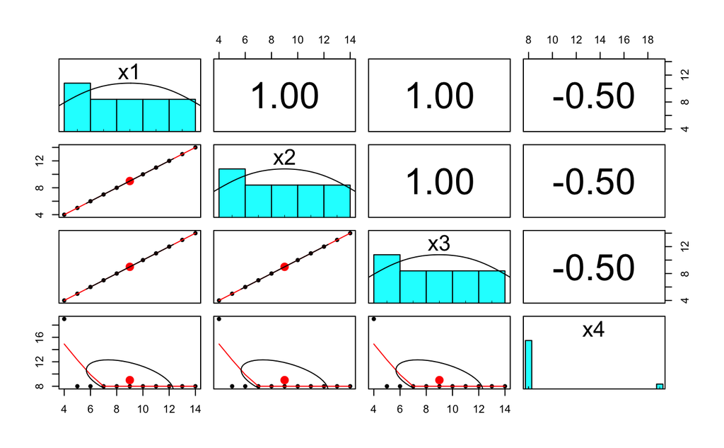

```r
library(psych)
pairs.panels(anscombe[c("x1", "x2", "x3", "x4")])
```

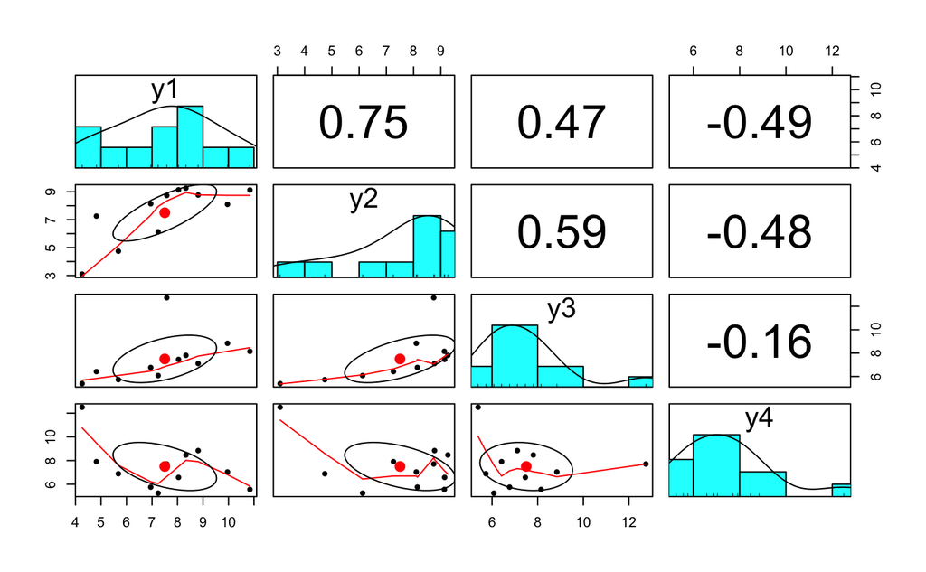

```r
pairs.panels(anscombe[c("y1", "y2", "y3", "y4")])
```

The above plot and the boxplot below shows that some datasets do vary. x1 - x3 look to have similar properties in both plots. However, x4, y1 and y2 are clearly different. y3 and y4 look similar but do have differences.

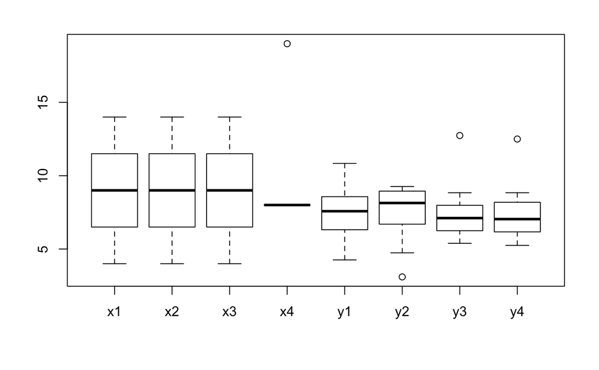

```r
boxplot(anscombe)
```

```r
IQR(anscombe$x1)
```

```
[1] 5
```

```r
e1071::skewness(anscombe$x1)
```

```
[1] 0
```

```r
IQR(anscombe$x2)
```

```
[1] 5
```

```r
e1071::skewness(anscombe$x2)
```

```
[1] 0
```

```r
IQR(anscombe$x3)
```

```
[1] 5
```

```r
e1071::skewness(anscombe$x3)
```

```
[1] 0
```

```r
IQR(anscombe$x4)
```

```
[1] 0
```

```r
e1071::skewness(anscombe$x4)
```

```
[1] 2.466911
```

```r
anscombe$x4
```

```
 [1]  8  8  8  8  8  8  8 19  8  8  8
```

```r
IQR(anscombe$y1)
```

```
[1] 2.255
```

```r
e1071::skewness(anscombe$y1)
```

```
[1] -0.04837355
```

```r
IQR(anscombe$y2)
```

```
[1] 2.255
```

```r
e1071::skewness(anscombe$y2)
```

```
[1] -0.9786929
```

```r
IQR(anscombe$y3)
```

```
[1] 1.73
```

```r
e1071::skewness(anscombe$y3)
```

```
[1] 1.38012
```

```r
IQR(anscombe$y4)
```

```
[1] 2.02
```

```r
e1071::skewness(anscombe$y4)
```

```
[1] 1.120774
```

Not sure I trust the correlation figures of 0.82 for all of the `(x,y)` relationships.

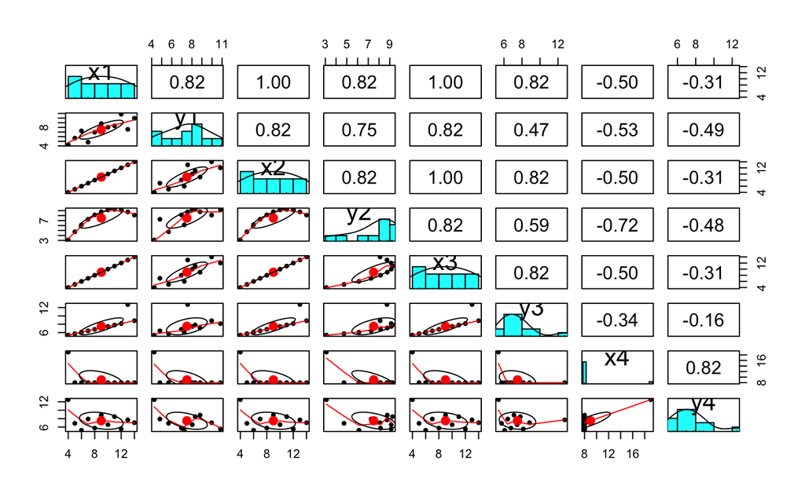

```r
psych::pairs.panels(anscombe[c("x1", "y1", "x2", "y2", "x3", "y3", "x4", "y4")])
```

Each of the plots of the `(x,y)` relationship between the two sets of data shows a different pattern on the scatterplot. `(x1, y1)` looks like you could fit a line through some of the points although some points are further away.

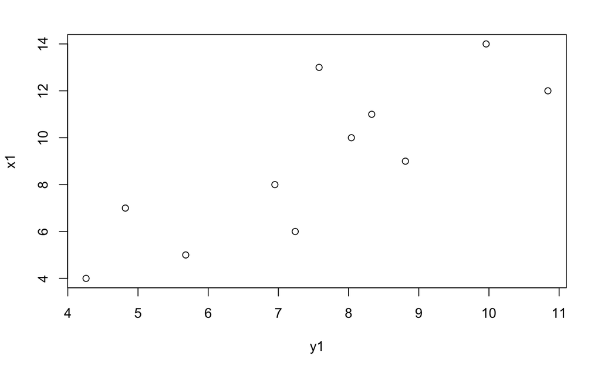

```r
plot(x1 ~ y1, data = anscombe)
```

This plot shows a curved relation ship between the two variables.

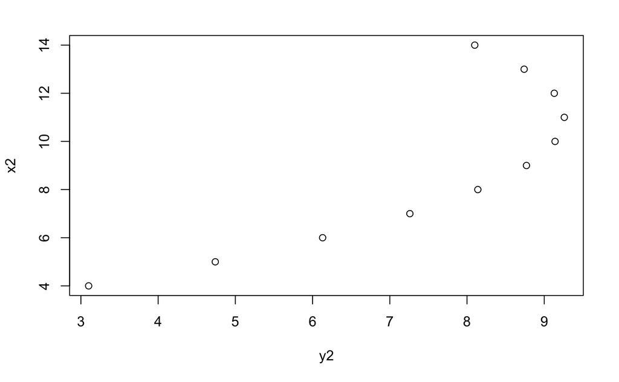

```r
plot(x2 ~ y2, data = anscombe)
```

This appears to show a straight-line relationship between the two variables but there is one significant outlier that does not fit with this.

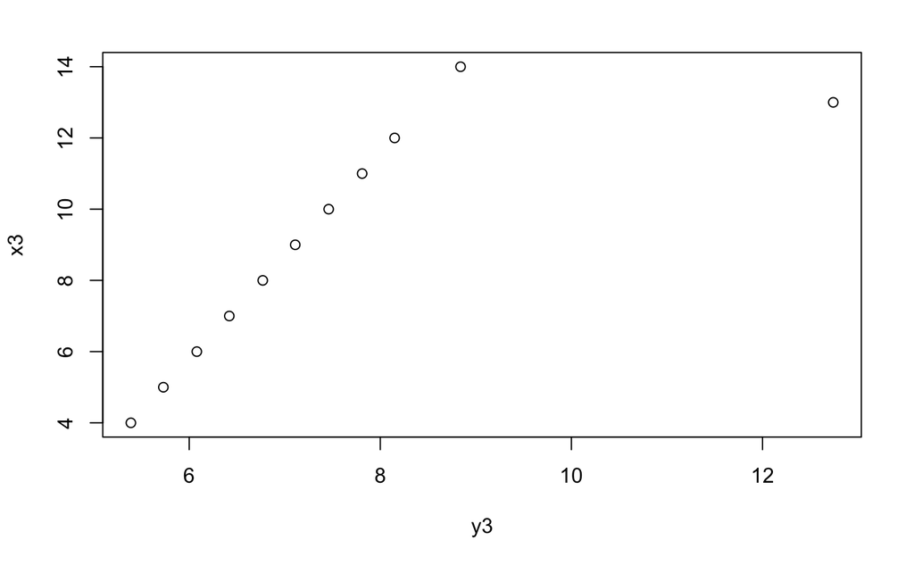

```r
plot(x3 ~ y3, data = anscombe)
```

Again, appears to show a stright-line relationship with one significant outlier.

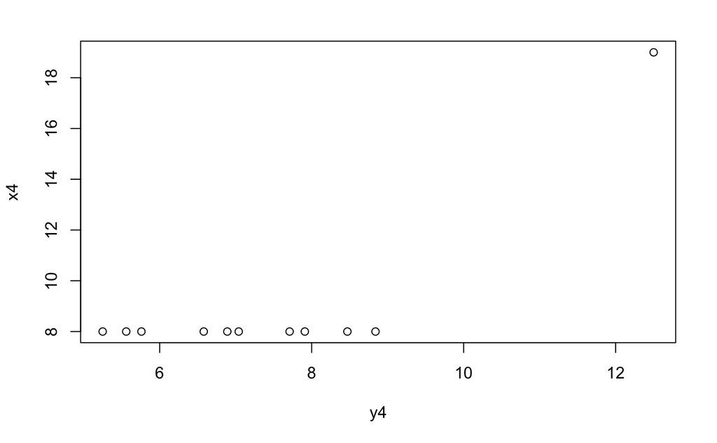

```r
plot(x4 ~ y4, data = anscombe)
```

**Correlation coefficients for each `(x,y)` set**

```r
cor(anscombe$x1, anscombe$y1)
```

```
[1] 0.8164205
```

```r
cor(anscombe$x2, anscombe$y2)
```

```
[1] 0.8162365
```

```r
cor(anscombe$x3, anscombe$y3)
```

```
[1] 0.8162867
```

```r
cor(anscombe$x4, anscombe$y4)
```

```
[1] 0.8165214
```